# Importing Necessary Libraries

```python
import pandas as pd
import numpy as np
import matplotlib.pyplot as plt
import seaborn as sns
import warnings
warnings.filterwarnings('ignore')
```

# Loading the Dataset

```python
df = pd.read_csv('beverage_sales_data.csv')
```

# Exploratory Data Analysis and Data Cleaning

```python
# First few rows from the dataset

df.head()
```

|  | Order_ID | Customer_ID | Customer_Type | Product | Category | Unit_Price | Quantity | Discount | Total_Price | Region | Order_Date |
| --- | --- | --- | --- | --- | --- | --- | --- | --- | --- | --- | --- |
| 0 | ORD1 | CUS1496 | B2B | Vio Wasser | Water | 1.66 | 53 | 0.10 | 79.18 | Baden-Württemberg | 2023-08-23 |
| 1 | ORD1 | CUS1496 | B2B | Evian | Water | 1.56 | 90 | 0.10 | 126.36 | Baden-Württemberg | 2023-08-23 |
| 2 | ORD1 | CUS1496 | B2B | Sprite | Soft Drinks | 1.17 | 73 | 0.05 | 81.14 | Baden-Württemberg | 2023-08-23 |
| 3 | ORD1 | CUS1496 | B2B | Rauch Multivitamin | Juices | 3.22 | 59 | 0.10 | 170.98 | Baden-Württemberg | 2023-08-23 |
| 4 | ORD1 | CUS1496 | B2B | Gerolsteiner | Water | 0.87 | 35 | 0.10 | 27.40 | Baden-Württemberg | 2023-08-23 |

```python
# Last few rows from the dataset

df.tail()
```

|  | Order_ID | Customer_ID | Customer_Type | Product | Category | Unit_Price | Quantity | Discount | Total_Price | Region | Order_Date |
| --- | --- | --- | --- | --- | --- | --- | --- | --- | --- | --- | --- |
| 8999905 | ORD2999999 | CUS7080 | B2C | Schwip Schwap | Soft Drinks | 1.27 | 2 | 0.0 | 2.54 | Sachsen | 2023-07-03 |
| 8999906 | ORD2999999 | CUS7080 | B2C | San Pellegrino | Water | 0.91 | 15 | 0.0 | 13.65 | Sachsen | 2023-07-03 |
| 8999907 | ORD3000000 | CUS6551 | B2B | Red Bull | Soft Drinks | 2.94 | 64 | 0.1 | 169.34 | Sachsen-Anhalt | 2022-04-09 |
| 8999908 | ORD3000000 | CUS6551 | B2B | Passion Fruit Juice | Juices | 4.04 | 79 | 0.1 | 287.24 | Sachsen-Anhalt | 2022-04-09 |
| 8999909 | ORD3000000 | CUS6551 | B2B | Vittel | Water | 0.38 | 9 | 0.1 | 3.08 | Sachsen-Anhalt | 2022-04-09 |

```python
# Number of rows and columns in dataset

df.shape
```

```
(8999910, 11)
```

```python
df.columns
```

```
Index(['Order_ID', 'Customer_ID', 'Customer_Type', 'Product', 'Category',
       'Unit_Price', 'Quantity', 'Discount', 'Total_Price', 'Region',
       'Order_Date'],
      dtype='object')
```

```python
df.info()
```

```
<class 'pandas.core.frame.DataFrame'>
RangeIndex: 8999910 entries, 0 to 8999909
Data columns (total 11 columns):
 #   Column         Dtype
---  ------         -----
 0   Order_ID       object
 1   Customer_ID    object
 2   Customer_Type  object
 3   Product        object
 4   Category       object
 5   Unit_Price     float64
 6   Quantity       int64
 7   Discount       float64
 8   Total_Price    float64
 9   Region         object
 10  Order_Date     object
dtypes: float64(3), int64(1), object(7)
memory usage: 755.3+ MB
```

```python
# Converting Order_Date to datetime

df['Order_Date'] = pd.to_datetime(df['Order_Date'])
```

```python
df.describe(include = 'object')
```

|  | Order_ID | Customer_ID | Customer_Type | Product | Category | Region |
| --- | --- | --- | --- | --- | --- | --- |
| count | 8999910 | 8999910 | 8999910 | 8999910 | 8999910 | 8999910 |
| unique | 3000000 | 10000 | 2 | 47 | 4 | 16 |
| top | ORD1 | CUS4693 | B2C | Hohes C Orange | Alcoholic Beverages | Hamburg |
| freq | 5 | 1120 | 5795405 | 337114 | 2251625 | 604054 |

```python
for col in df.describe(include = 'object').columns:
    print(col)
    print(df[col].unique())
    print('-'*50)
```

```
Order_ID
['ORD1' 'ORD2' 'ORD3' ... 'ORD2999998' 'ORD2999999' 'ORD3000000']
--------------------------------------------------
Customer_ID
['CUS1496' 'CUS2847' 'CUS1806' ... 'CUS7701' 'CUS4767' 'CUS6117']
--------------------------------------------------
Customer_Type
['B2B' 'B2C']
--------------------------------------------------
Product
['Vio Wasser' 'Evian' 'Sprite' 'Rauch Multivitamin' 'Gerolsteiner'
 'Sauvignon Blanc' 'Tomato Juice' 'Vittel' 'San Pellegrino' 'Mountain Dew'
 'Hohes C Orange' 'Red Bull' 'Chardonnay' 'Tanqueray' 'Rotkäppchen Sekt'
 'Mango Juice' 'Apollinaris' 'Riesling' 'Granini Apple' 'Fanta' 'Rockstar'
 'Club Mate' 'Krombacher' 'Erdinger Weißbier' 'Volvic Touch' 'Volvic'
 'Schwip Schwap' 'Fritz-Kola' 'Coca-Cola' 'Selters' 'Cranberry Juice'
 'Mezzo Mix' "Beck's" 'Passion Fruit Juice' 'Monster' 'Augustiner' 'Pepsi'
 'Merlot' 'Kölsch' 'Bacardi' 'Warsteiner' 'Moët & Chandon' 'Jever'
 'Veuve Clicquot' 'Johnnie Walker' 'Havana Club' 'Jack Daniels']
--------------------------------------------------
Category
['Water' 'Soft Drinks' 'Juices' 'Alcoholic Beverages']
--------------------------------------------------
Region
['Baden-Württemberg' 'Schleswig-Holstein' 'Hamburg' 'Bayern' 'Saarland'
 'Thüringen' 'Brandenburg' 'Nordrhein-Westfalen' 'Mecklenburg-Vorpommern'
 'Sachsen-Anhalt' 'Niedersachsen' 'Rheinland-Pfalz' 'Bremen' 'Sachsen'
 'Hessen' 'Berlin']
--------------------------------------------------
```

```python
# checking for the missing values

df.isnull().sum()
```

```
Order_ID         0
Customer_ID      0
Customer_Type    0
Product          0
Category         0
Unit_Price       0
Quantity         0
Discount         0
Total_Price      0
Region           0
Order_Date       0
dtype: int64
```

```python
pd.options.display.float_format = '{:,.2f}'.format
df.describe()
```

|  | Unit_Price | Quantity | Discount | Total_Price | Order_Date |
| --- | --- | --- | --- | --- | --- |
| count | 8,999,910.00 | 8,999,910.00 | 8,999,910.00 | 8,999,910.00 | 8999910 |
| mean | 5.82 | 23.14 | 0.03 | 130.74 | 2022-07-01 16:18:18.126182144 |
| min | 0.32 | 1.00 | 0.00 | 0.30 | 2021-01-01 00:00:00 |
| 25% | 1.05 | 6.00 | 0.00 | 8.40 | 2021-10-01 00:00:00 |
| 50% | 1.75 | 11.00 | 0.00 | 21.14 | 2022-07-02 00:00:00 |
| 75% | 3.21 | 30.00 | 0.05 | 69.49 | 2023-04-01 00:00:00 |
| max | 169.53 | 100.00 | 0.15 | 14,295.30 | 2023-12-30 00:00:00 |
| std | 14.70 | 26.89 | 0.04 | 509.69 | NaN |

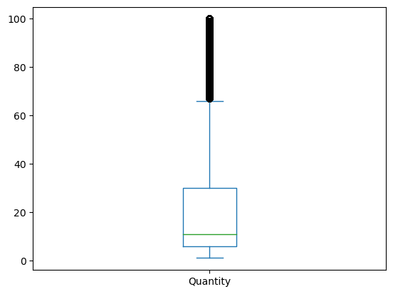

```python
# Visualizing the outliers

df['Quantity'].plot(kind = 'box')
```

# Separate Analysis and Summary Statistics

```python
# Creating separate DataFrames for B2B and B2C

df_b2b = df[df['Customer_Type'] == 'B2B']
df_b2c = df[df['Customer_Type'] == 'B2C']
```

# Reason for Separate Analysis:

# One of the key objectives is to "Evaluate the impact of discounts on revenue and profit margins for B2B customers."

# B2B customers often exhibit different purchasing behaviors (e.g., bulk orders, negotiated discounts) compared to B2C customers.

# Analyzing them separately allows us to isolate the specific impact of discounts on the B2B segment, as required by the objective,

# and avoid misleading conclusions that might arise from combining both segments. Furthermore, B2B customers are likely the source of the outliers seen in the overall analysis.

```python
# Calculate summary statistics for each segment

pd.options.display.float_format = '{:,.2f}'.format
print("B2B Summary Statistics:")
print(df_b2b[['Unit_Price','Quantity','Discount','Total_Price']].describe())

print("\nB2C Summary Statistics:")
print(df_b2c[['Unit_Price','Quantity','Discount','Total_Price']].describe())
```

```
B2B Summary Statistics:
        Unit_Price     Quantity     Discount  Total_Price
count 3,204,505.00 3,204,505.00 3,204,505.00 3,204,505.00
mean          5.63        50.52         0.08       281.36
std          13.21        28.87         0.03       810.75
min           0.32         1.00         0.05         0.30
25%           1.03        26.00         0.05        31.35
50%           1.81        51.00         0.10        77.20
75%           3.04        76.00         0.10       167.58
max         169.53       100.00         0.15    14,295.30

B2C Summary Statistics:
        Unit_Price     Quantity     Discount  Total_Price
count 5,795,405.00 5,795,405.00 5,795,405.00 5,795,405.00
mean          5.92         8.00         0.00        47.46
std          15.46         4.32         0.00       143.17
min           0.46         1.00         0.00         0.46
25%           1.07         4.00         0.00         6.20
50%           1.75         8.00         0.00        13.02
75%           3.21        12.00         0.00        26.28
max         112.46        15.00         0.00     1,686.90
```

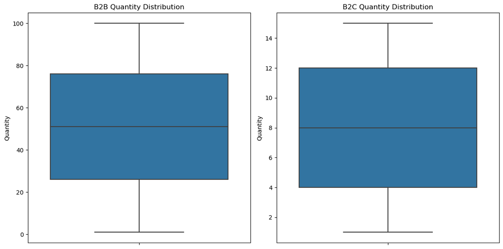

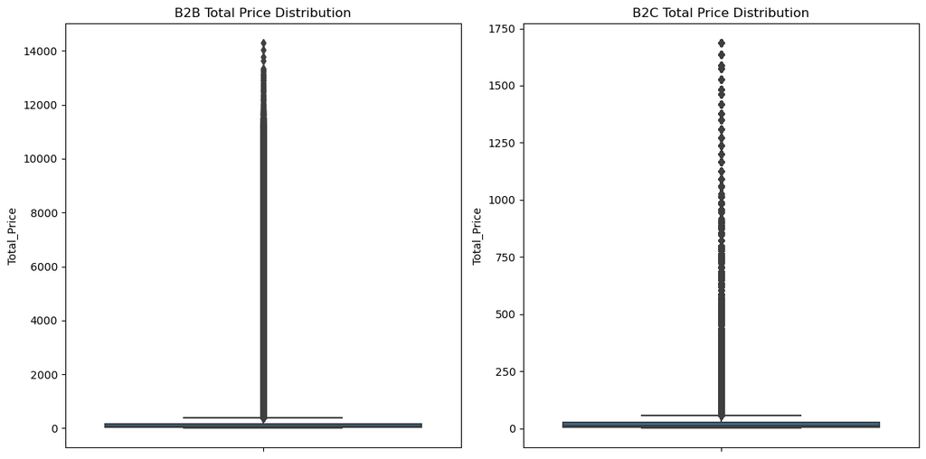

```python
# Box plots
plt.figure(figsize=(12, 6))

# Create a subplot for Quantity of B2B
plt.subplot(1, 2, 1)
sns.boxplot(y=df_b2b['Quantity'])
plt.title('B2B Quantity Distribution')

 # Create a subplot for Quantity of B2C
plt.subplot(1, 2, 2)
sns.boxplot(y=df_b2c['Quantity'])
plt.title('B2C Quantity Distribution')

plt.tight_layout()  # Adjust layout to prevent overlapping titles
plt.show()


# Create a subplot for Total Price of B2B
plt.figure(figsize=(12, 6))
plt.subplot(1, 2, 1)
sns.boxplot(y=df_b2b['Total_Price'])
plt.title('B2B Total Price Distribution')

 # Create a subplot for Total Price B2C
plt.subplot(1, 2, 2)
sns.boxplot(y=df_b2c['Total_Price'])
plt.title('B2C Total Price Distribution')

plt.tight_layout()
plt.show()
```

# 1. Analyze Revenue and Profitability by Customer Type

# Objective: Understand the revenue contribution and profitability of B2B vs. B2C customers.

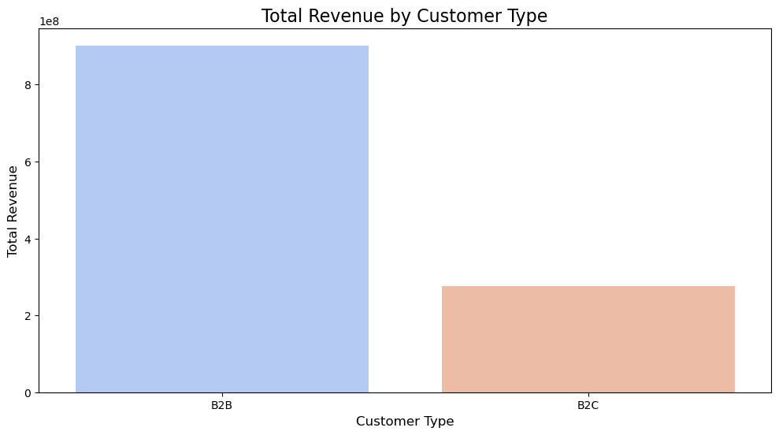

```python
# Revenue and Profitability by Customer Type

customer_summary = df.groupby('Customer_Type').agg({
    'Total_Price': 'sum',
    'Discount': 'mean',
    'Quantity': 'sum'
}).reset_index()

customer_summary.rename(columns={
    'Total_Price': 'Total_Revenue',
    'Discount': 'Avg_Discount',
    'Quantity': 'Total_Quantity'
}, inplace=True)

# Visualization
plt.figure(figsize=(12, 6))
sns.barplot(data=customer_summary, x='Customer_Type', y='Total_Revenue', palette='coolwarm')
plt.title('Total Revenue by Customer Type', fontsize=16)
plt.xlabel('Customer Type', fontsize=12)
plt.ylabel('Total Revenue', fontsize=12)
plt.show()
```

# 2. Impact of Discounts on B2B Revenue

# Objective: Assess how discounts affect B2B revenue and profit margins.

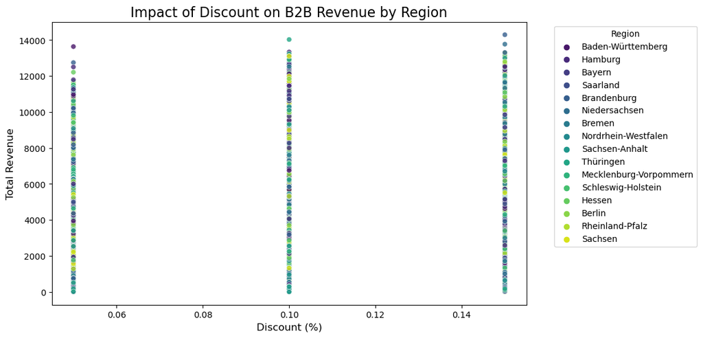

```python
# Scatter Plot: Discount vs Total Price for B2B

plt.figure(figsize=(10, 6))
sns.scatterplot(data=df_b2b, x='Discount', y='Total_Price', hue='Region', palette='viridis', alpha=0.8)
plt.title('Impact of Discount on B2B Revenue by Region', fontsize=16)
plt.xlabel('Discount (%)', fontsize=12)
plt.ylabel('Total Revenue', fontsize=12)
plt.legend(title='Region', bbox_to_anchor=(1.05, 1), loc='upper left')
plt.show()
```

# 3. Regional Sales Performance

# Objective: Identify high-performing regions for targeted marketing or sales optimization

```
Revenue by Region:
 Region
Hamburg                  82,470,771.98
Hessen                   78,400,110.19
Saarland                 78,390,587.15
Rheinland-Pfalz          75,838,676.99
Mecklenburg-Vorpommern   75,517,247.16
Thüringen                75,324,865.47
Berlin                   74,567,927.53
Bayern                   72,825,399.18
Niedersachsen            71,959,050.52
Sachsen                  71,946,991.38
Baden-Württemberg        71,594,838.90
Nordrhein-Westfalen      71,393,803.70
Brandenburg              71,349,031.11
Schleswig-Holstein       70,317,829.38
Sachsen-Anhalt           69,765,543.62
Bremen                   65,018,489.09
Name: Total_Price, dtype: float64
```

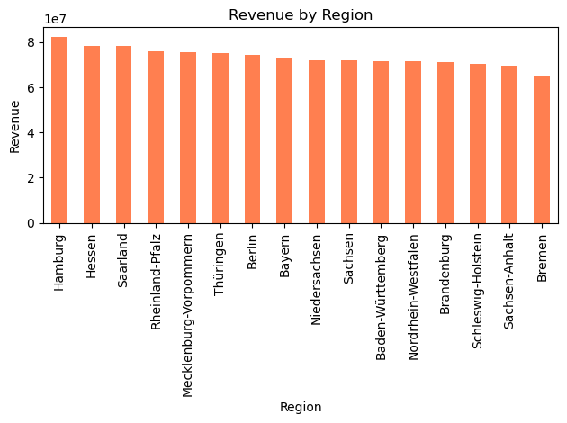

```python
region_revenue = df.groupby('Region')['Total_Price'].sum().sort_values(ascending=False)
print("\nRevenue by Region:\n", region_revenue)
region_revenue.plot(kind='bar', title='Revenue by Region', color='coral')
plt.ylabel('Revenue')
plt.xlabel('Region')
plt.tight_layout()
plt.show()
```

# 4. Product-Level Profitability Analysis

# Objective: Identify the most and least profitable products

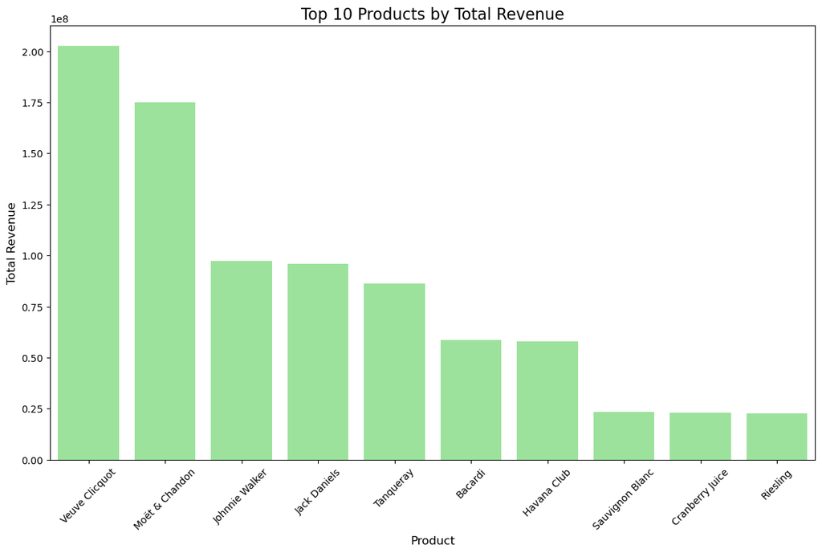

```python
# Profitability by Product
product_summary = df.groupby('Product').agg({
    'Total_Price': 'sum',
    'Quantity': 'sum',
    'Unit_Price': 'mean'
}).reset_index()

product_summary['Revenue_Per_Unit'] = product_summary['Total_Price'] / product_summary['Quantity']

# Visualization
top_products = product_summary.sort_values('Total_Price', ascending=False).head(10)

plt.figure(figsize=(14, 8))
sns.barplot(data=top_products, x='Product', y='Total_Price', color='lightgreen')
plt.title('Top 10 Products by Total Revenue', fontsize=16)
plt.xlabel('Product', fontsize=12)
plt.ylabel('Total Revenue', fontsize=12)
plt.xticks(rotation=45)
plt.show()
```

# 5. Trend Analysis (Monthly Sales)

# Objective: Analyze sales trends over time to identify seasonality or growth patterns

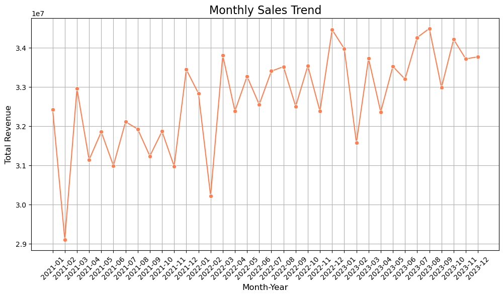

```python
# Monthly Sales Analysis
df['Month_Year'] = df['Order_Date'].dt.to_period('M')

# Group and convert 'Month_Year' to string for plotting
monthly_sales = df.groupby('Month_Year').agg({'Total_Price': 'sum'}).reset_index()
monthly_sales['Month_Year'] = monthly_sales['Month_Year'].astype(str)  # Convert to string

# Visualization
plt.figure(figsize=(12, 6))
sns.lineplot(data=monthly_sales, x='Month_Year', y='Total_Price', marker='o', color='coral')
plt.title('Monthly Sales Trend', fontsize=16)
plt.xlabel('Month-Year', fontsize=12)
plt.ylabel('Total Revenue', fontsize=12)
plt.xticks(rotation=45)
plt.grid()
plt.show()
```

# 6. Juice Performance Analysis

# Objective: Assess the profitability and sales of Juices compared to other product categories.

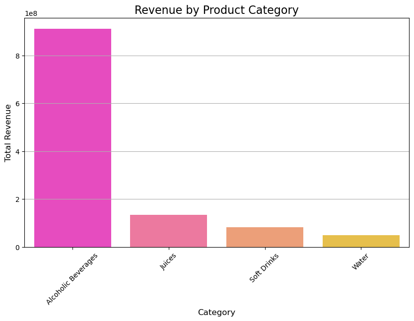

```python
# Filter for Juices
juices = df[df['Category'].str.contains('Juices', case=False, na=False)]

# Revenue Comparison: Juices vs Other Categories
category_summary = df.groupby('Category').agg({'Total_Price': 'sum'}).reset_index()

# Visualization
plt.figure(figsize=(10, 6))
sns.barplot(data=category_summary, x='Category', y='Total_Price', palette='spring')
plt.title('Revenue by Product Category', fontsize=16)
plt.xlabel('Category', fontsize=12)
plt.ylabel('Total Revenue', fontsize=12)
plt.xticks(rotation=45)
plt.grid(axis='y')
plt.show()
```

# Objective: Evaluate the performance of the "Juices" category across regions and over time.

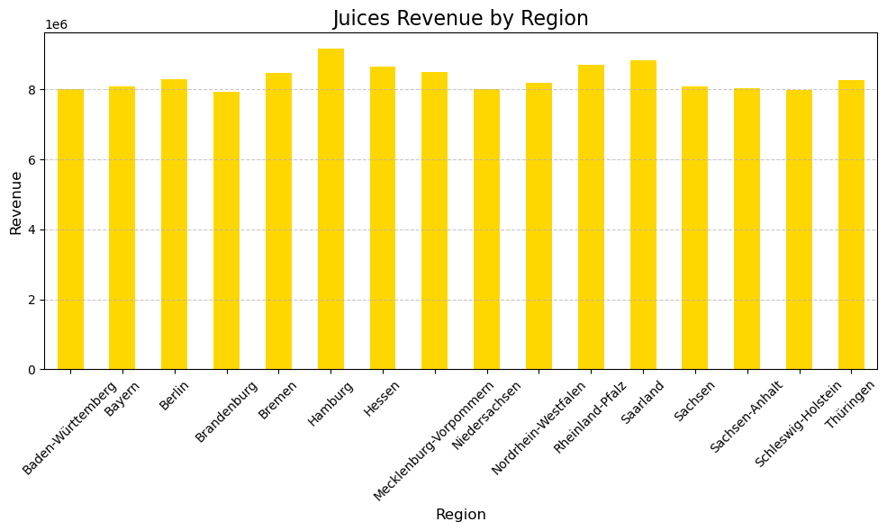

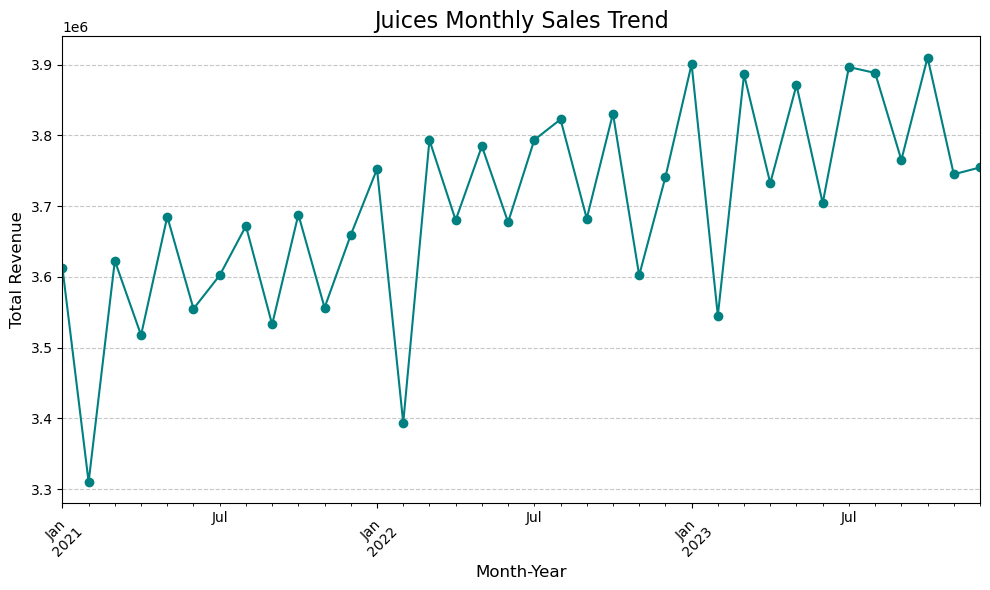

```python
juices = df[df['Category'].str.contains('Juices', case=False, na=False)]
juice_revenue_by_region = juices.groupby('Region')['Total_Price'].sum()
plt.figure(figsize=(10, 6))
juice_revenue_by_region.plot(kind='bar', color='gold')
plt.title('Juices Revenue by Region', fontsize=16)
plt.ylabel('Revenue', fontsize=12)
plt.xlabel('Region', fontsize=12)
plt.xticks(rotation=45)
plt.grid(axis='y', linestyle='--', alpha=0.7)
plt.tight_layout()
plt.show()


juice_monthly_sales = juices.groupby('Month_Year')['Total_Price'].sum()
plt.figure(figsize=(10, 6))
juice_monthly_sales.plot(marker='o', color='teal')
plt.title('Juices Monthly Sales Trend', fontsize=16)
plt.ylabel('Total Revenue', fontsize=12)
plt.xlabel('Month-Year', fontsize=12)
plt.xticks(rotation=45)
plt.grid(axis='y', linestyle='--', alpha=0.7)
plt.tight_layout()
plt.show()
```

# 7. Impact of Discounts on Revenue (B2B Only)

# Objective: Assess how discounts affect revenue in the B2B segment.

```python
b2b_discount_impact = df_b2b.groupby('Category').apply(lambda x: pd.Series({
    'Total Revenue': x['Total_Price'].sum(),
    'Revenue Without Discount': (x['Total_Price'] / (1-x['Discount'])).sum(),
    'Discount Amount': ((x['Total_Price'] / (1-x['Discount'])).sum() - x['Total_Price'].sum())
}))
print("\nB2B Discount Impact:\n", b2b_discount_impact)
```

```
B2B Discount Impact:
                      Total Revenue  Revenue Without Discount  Discount Amount
Category
Alcoholic Beverages 697,888,317.54            772,654,469.31    74,766,151.77
Juices              101,870,692.21            112,672,904.62    10,802,212.41
Soft Drinks          64,350,493.19             71,176,250.50     6,825,757.31
Water                37,510,109.33             41,526,416.90     4,016,307.57
```

# 8. Additional Analysis to derive deeper insights into customer behavior and discount patterns.

# Objective: To assess the purchasing patterns of B2B and B2C customers through their average transaction values.

```python
# Average Transaction Value by Customer Type
df['Transaction_Value'] = df['Total_Price'] / df['Quantity']
avg_transaction_value = df.groupby('Customer_Type')['Transaction_Value'].mean()
print("\nAverage Transaction Value by Customer Type:\n", avg_transaction_value)
```

```
Average Transaction Value by Customer Type:
 Customer_Type
B2B   5.13
B2C   5.92
Name: Transaction_Value, dtype: float64
```

# Objective: To understand the distribution and frequency of discounts offered to B2B customers.

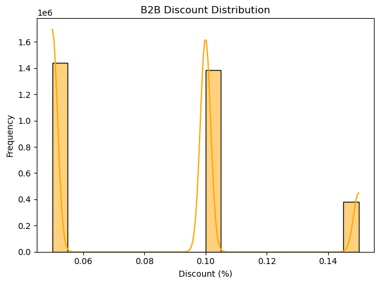

```python
# Visualization of Discount Distribution for B2B Customers
sns.histplot(df_b2b['Discount'], kde=True, bins=20, color='orange')
plt.title('B2B Discount Distribution')
plt.xlabel('Discount (%)')
plt.ylabel('Frequency')
plt.tight_layout()
plt.show()
```